# Models

January 17, 2017

## Problem Setting

- Data: Observe for each case \(i\) \((Y_i, X_i)\)
- Response or dependent variable \(Y_i\)
- Predictor(s) or **independent** variable \(X_i\)

Goals:

- Exploring distribution of \(p(y| X = x)\) as a function of \(x\)
- Understanding the mean (variability) in \(Y\) as a function of \(x\) : \(E(Y \mid X =x ) = f(X)\)

## Special cases:

- regression (normal \(Y\)) or additive error model
- classification (binary or Bernoulli \(Y\) where probability \(p(Y = 1 \mid X)\) depends on \(x\))
- exponential family models
  - Poisson regression (counts)
  - Gamma regression (continous, positive)
- Survival models

## Additive Error Model

- Assume \(E[\epsilon_i] = 0\) for \(i=1,\ldots,n,\) \[ Y_i = f(X_i) + \epsilon_i \]
- Regression function \(E(Y \mid x) = f(x)\)
- ideal or optimal predictor of \(Y\) given \(X = x\)
- minimizes \(E[(Y - g(x))^2 \mid X =x]\) over all functions \(g(x)\) at all points \(X=x\)
- for prediction \(\epsilon = Y - f(x)\) is *irreducible error* as even if we know \(f(x)\) there are still errors in predicting \(Y\)
- for any estimator \(\hat{f}(x)\) we have \[E[(Y - \hat{f}(x))^2 \mid X = x] = \underbrace{(f(x) - \hat{f}(x)))^2}_{Reducible} + \underbrace{\textsf{Var}(\epsilon)}_{Irreducible} \]

## Linear Regression

- Taylors series expansion of regression function about point \(x_0\) \[f(x_i) = f(x_0) + f'(x_0)(x_i - x_0) + \textsf{ Remainder}\]  
  leads to locally linear approximation \[ Y_i = \beta_0 + X_i \beta_1 + \varepsilon_i \]
- \(\varepsilon_i:\) errors (sampling/measurement errors \(\epsilon\), lack of fit)

## Regression in Matrix Notation

Simple Linear Regression:

\[Y_i = \beta_0 + x_i \beta_1 + \epsilon_i \text{ for } i = 1, \ldots, n\]

## BIG PICTURE:

\[ \mathbf{Y} = \mathbf{X} \boldsymbol{\beta} + \boldsymbol{\varepsilon} \stackrel{iid}{\sim} N(0,\sigma^2)\]

- Estimate parameters \((\beta, \sigma)\)
- interpretation of parameters: \(\beta, \sigma\)
- assess model fit — adequate? good? if inadequate, how?
- move to more complicated model?
- predict new (``future'') responses at new \(x_{n+1}, \ldots\)
- how much variability does \(x\) explain?

## Body Fat Data

- For a group of \(252\) male subjects, various body measurements were obtained
- An accurate measurement of the percentage of body fat is recorded for each
- Goal is to use the other body measurements as a proxy for predicting body fat
- Understand how changing one measurement may lead to changes in Bodyfat

## Data

```r
library(BAS)
data(bodyfat)  #from BAS   help(bodyfat)
dim(bodyfat)
```

```
## [1] 252  15
```

```r
summary(bodyfat)  # anything strange ?
```

```
##     Density         Bodyfat           Age            Weight
##  Min.   :0.995   Min.   : 0.00   Min.   :22.00   Min.   :118.5
##  1st Qu.:1.041   1st Qu.:12.47   1st Qu.:35.75   1st Qu.:159.0
##  Median :1.055   Median :19.20   Median :43.00   Median :176.5
##  Mean   :1.056   Mean   :19.15   Mean   :44.88   Mean   :178.9
##  3rd Qu.:1.070   3rd Qu.:25.30   3rd Qu.:54.00   3rd Qu.:197.0
##  Max.   :1.109   Max.   :47.50   Max.   :81.00   Max.   :363.1
##      Height           Neck           Chest           Abdomen
##  Min.   :29.50   Min.   :31.10   Min.   : 79.30   Min.   : 69.40
##  1st Qu.:68.25   1st Qu.:36.40   1st Qu.: 94.35   1st Qu.: 84.58
##  Median :70.00   Median :38.00   Median : 99.65   Median : 90.95
##  Mean   :70.15   Mean   :37.99   Mean   :100.82   Mean   : 92.56
##  3rd Qu.:72.25   3rd Qu.:39.42   3rd Qu.:105.38   3rd Qu.: 99.33
##  Max.   :77.75   Max.   :51.20   Max.   :136.20   Max.   :148.10
##       Hip            Thigh            Knee           Ankle
##  Min.   : 85.0   Min.   :47.20   Min.   :33.00   Min.   :19.1
##  1st Qu.: 95.5   1st Qu.:56.00   1st Qu.:36.98   1st Qu.:22.0
##  Median : 99.3   Median :59.00   Median :38.50   Median :22.8
##  Mean   : 99.9   Mean   :59.41   Mean   :38.59   Mean   :23.1
##  3rd Qu.:103.5   3rd Qu.:62.35   3rd Qu.:39.92   3rd Qu.:24.0
##  Max.   :147.7   Max.   :87.30   Max.   :49.10   Max.   :33.9
##      Biceps         Forearm          Wrist
##  Min.   :24.80   Min.   :21.00   Min.   :15.80
##  1st Qu.:30.20   1st Qu.:27.30   1st Qu.:17.60
##  Median :32.05   Median :28.70   Median :18.30
##  Mean   :32.27   Mean   :28.66   Mean   :18.23
##  3rd Qu.:34.33   3rd Qu.:30.00   3rd Qu.:18.80
##  Max.   :45.00   Max.   :34.90   Max.   :21.40
```

## Pairs Plots

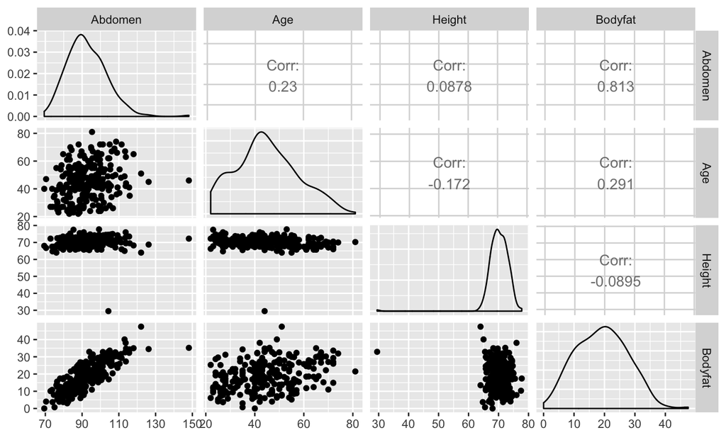

```r
library(GGally)
ggpairs(bodyfat, columns=c(8,3,5,2))
```

## Ordinary Least Squares

- OLS estimates of parameters \(\beta_0\) and \(\beta\) minimize sum of squared errors \[ \sum_{i=1}^n (Y_i - (\beta_0 + X_i \beta_1))^2\]

\[ (\mathbf{Y} - \mathbf{X} \boldsymbol{\beta})^T(\mathbf{Y} - \mathbf{X} \boldsymbol{\beta})\]

- OLS estimate of \(\boldsymbol{\beta}\) \[\hat{\boldsymbol{\beta}} = (\mathbf{X}^T\mathbf{X})^{-1} \mathbf{X}^T\mathbf{Y} \]